# Statistical Inference Course Project: Part 1

Qingxiao Dong

February 22, 2015

This is the project for the statistical inference class (Data Science specialization). The project consists of two parts:

1. A simulation exercise.
2. Basic inferential data analysis.

Now in the first portion of the class, we’re going to simulate the exponential distribution and compare it to theoretical distribution.

### Simulations

The exponential distribution can be simulated in R with `rexp(n, lambda)` where lambda is the rate parameter. The mean of exponential distribution is 1/lambda and the standard deviation is also 1/lambda. For these simulations, we set lambda to 0.2 and investigate the distribution of averages of 40 exponentials. For this purpose, we perform a thousand simulations.

```r
# set seed for reproducability
set.seed(31)
# set lambda to 0.2
lambda <- 0.2
# 40 samples
n <- 40
# 1000 simulations
simulations <- 1000
# simulate
simulated_exponentials <- replicate(simulations, rexp(n, lambda))
# calculate mean of exponentials
means_exponentials <- apply(simulated_exponentials, 2, mean)
```

### Results

##### 1. Show the sample mean and compare it to the theoretical mean of the distribution.

```r
# sample mean
sample_mean <- mean(means_exponentials)
sample_mean
```

```
## [1] 4.993867
```

```r
# theoretical mean
theory_mean <- 1/lambda
theory_mean
```

```
## [1] 5
```

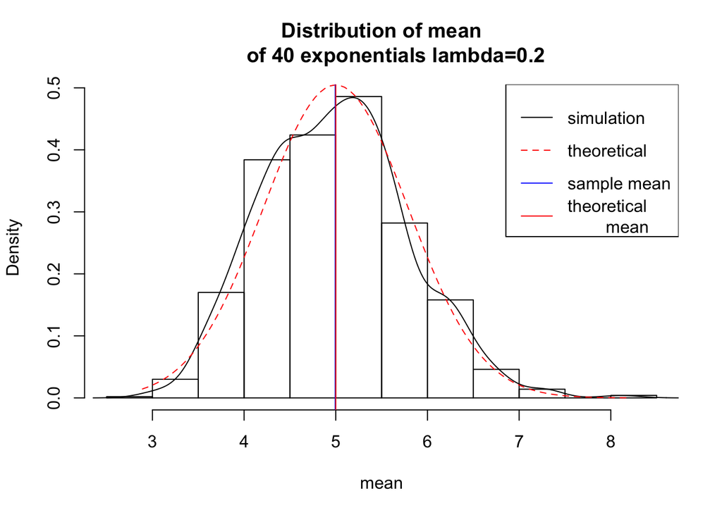

```r
# visualization
hist(means_exponentials, prob = T, xlab = "mean", main = "Distribution of mean
     of 40 exponentials lambda=0.2")
lines(density(means_exponentials))
xfit <- seq(min(means_exponentials), max(means_exponentials), length=100)
yfit <- dnorm(xfit, mean=1/lambda, sd=(1/lambda/sqrt(n)))
lines(xfit, yfit, pch=22, col="red", lty=2)
legend('topright', c("simulation", "theoretical", "sample mean", "theoretical
        mean"), lty=c(1,2,1,1), col=c("black", "red", "blue", "red"))
abline(v=sample_mean, col="blue")
abline(v=theory_mean, col="red")
```

As seen in the figure, the sample mean is very close to the theoretical mean of the distribution.

##### 2. Show how variable the sample is (via variance) and compare it to the theoretical variance of the distribution.

```r
# standard deviation of sample
sd(means_exponentials)
```

```
## [1] 0.7931608
```

```r
# theoretical standard deviation
(1/lambda)/sqrt(n)
```

```
## [1] 0.7905694
```

##### 3. Show that the distribution is approximately normal.

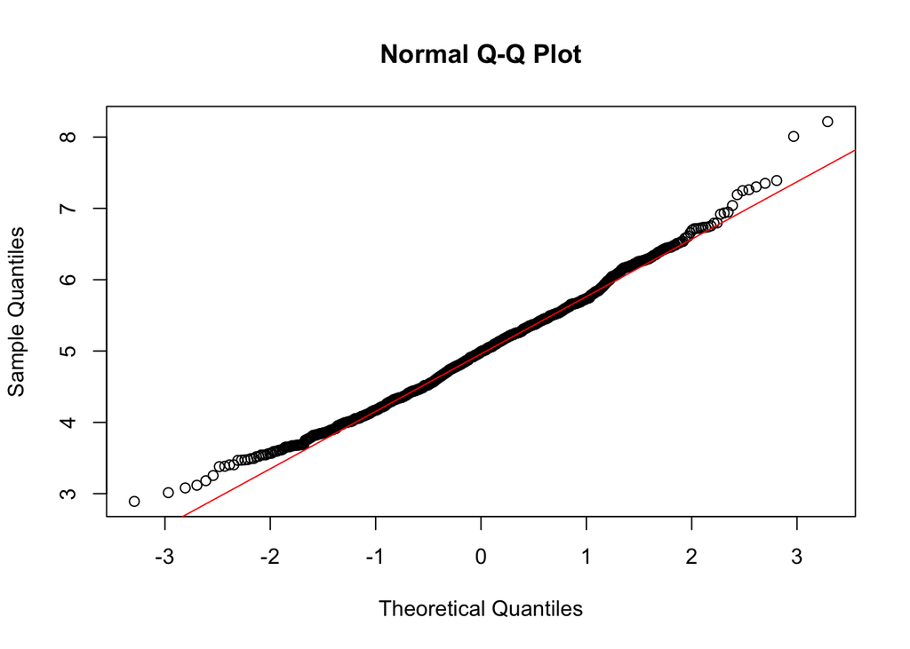

```r
# use qqplot and qqline to compare the distribution of averages of 40
# exponentials to a normal distribution
qqnorm(means_exponentials)
qqline(means_exponentials, col = 2)
```

As seen in the figure, the distribution of averages of 40 exponentials is very close to a normal distribution.